# Create a scenario in which some main effects (main=additive) will be of the size 0.7. Use simulations to calculate the power of F test for main effects and power of test for interactions.

We assume that residuals \( \varepsilon \sim \mathcal{N}(0,1) \). Recall that power of statistical test in defined by \( \mathbb{P}(\text{reject }\mathrm{H_0} | \mathrm{H_{alternative}} \text{ is true}) \).

### Create a scenario in which some main effects (main=additive) will be of the size 0.7. Use simulations to calculate the power of F test for main effects and power of test for interactions.

```r
set.seed(77)

# size of (whole) sample
N <- 900
# number of groups (variable 1)
k1 <- 2
# number of groups (variable 2)
k2 <- 3
# number of obserwations in each group
m1 <- N/k1
m2 <- N/k2

# only residuals
Y <- rnorm(N)

# groups
x1 <- rep(c("I", "II"), times=m1)
x2 <- rep(c("A", "B", "C"), times=m2)

# differing means
Y[x1=="II"] <- Y[x1=="II"] + 2

Y[x2=="A"] <- Y[x2=="A"] + 0.1
Y[x2=="B"] <- Y[x2=="B"] + 0.3
Y[x2=="C"] <- Y[x2=="C"] + 0.85

myData <- data.frame(Y, x1, x2)
```

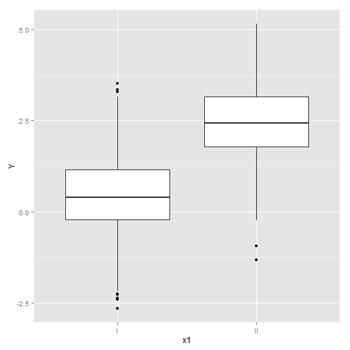

```r
library("ggplot2")
ggplot(myData, aes(x=x1, y=Y)) + geom_boxplot()
```

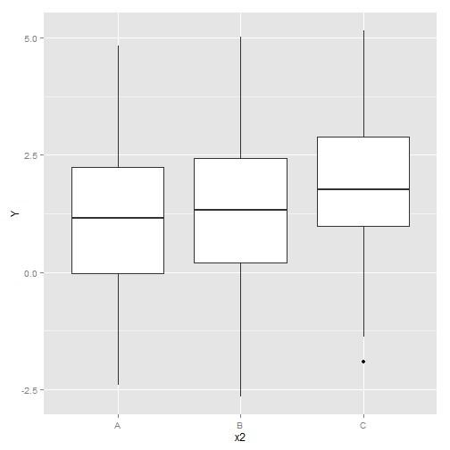

```r
ggplot(myData, aes(x=x2, y=Y)) + geom_boxplot()
```

Boxplots indicate diffrences in means between groups.

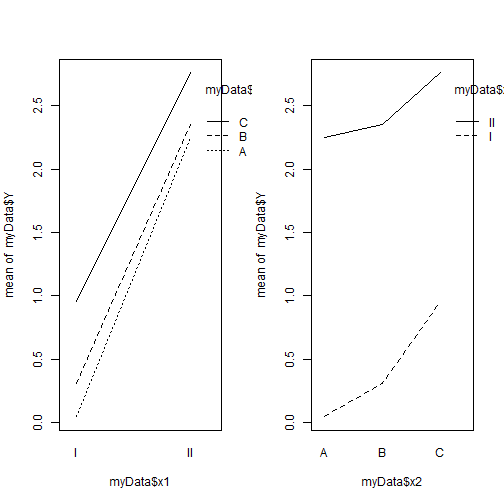

```r
par(mfrow=c(1,2))
interaction.plot(myData$x1, myData$x2, myData$Y)
interaction.plot(myData$x2, myData$x1, myData$Y)
```

```r
model1 <- lm(Y ~ x1 + x2, data = myData)
summary(model1)
```

```
##
## Call:
## lm(formula = Y ~ x1 + x2, data = myData)
##
## Residuals:
##     Min      1Q  Median      3Q     Max
## -3.4662 -0.6699 -0.0038  0.6499  3.1924
##
## Coefficients:
##             Estimate Std. Error t value Pr(>|t|)
## (Intercept)  0.13866    0.06537   2.121   0.0342 *
## x1II         2.01801    0.06537  30.872   <2e-16 ***
## x2B          0.18385    0.08006   2.296   0.0219 *
## x2C          0.71038    0.08006   8.873   <2e-16 ***
## ---
## Signif. codes:  0 '***' 0.001 '**' 0.01 '*' 0.05 '.' 0.1 ' ' 1
##
## Residual standard error: 0.9805 on 896 degrees of freedom
## Multiple R-squared:  0.5367, Adjusted R-squared:  0.5351
## F-statistic:   346 on 3 and 896 DF,  p-value: < 2.2e-16
```

The main effect for group C (variable x2) is of the size 0.7 (as the standard deviation equals 1 in our case).

```r
model2 <- lm(Y ~ x1 * x2, data = myData)
summary(model2)
```

```
##
## Call:
## lm(formula = Y ~ x1 * x2, data = myData)
##
## Residuals:
##     Min      1Q  Median      3Q     Max
## -3.5605 -0.6618 -0.0121  0.6415  3.2049
##
## Coefficients:
##             Estimate Std. Error t value Pr(>|t|)
## (Intercept)  0.04437    0.07986   0.556   0.5786
## x1II         2.20657    0.11294  19.537  < 2e-16 ***
## x2B          0.26559    0.11294   2.352   0.0189 *
## x2C          0.91148    0.11294   8.070 2.25e-15 ***
## x1II:x2B    -0.16348    0.15972  -1.024   0.3063
## x1II:x2C    -0.40221    0.15972  -2.518   0.0120 *
## ---
## Signif. codes:  0 '***' 0.001 '**' 0.01 '*' 0.05 '.' 0.1 ' ' 1
##
## Residual standard error: 0.9781 on 894 degrees of freedom
## Multiple R-squared:   0.54,  Adjusted R-squared:  0.5374
## F-statistic: 209.9 on 5 and 894 DF,  p-value: < 2.2e-16
```

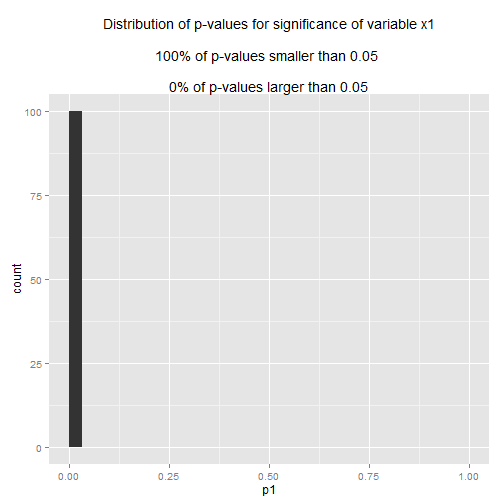

```r
set.seed(777)

M <- 100
pvals <- replicate(M, {

  Y <- rnorm(N)

  # differing means
  Y[x1=="II"] <- Y[x1=="II"] + 2

  Y[x2=="A"] <- Y[x2=="A"] + 0.1
  Y[x2=="B"] <- Y[x2=="B"] + 0.3
  Y[x2=="C"] <- Y[x2=="C"] + 0.85

  myData <- data.frame(Y, x1=factor(x1), x2=factor(x2))

  tmp <- summary(aov(Y~x1+x2, data=myData))
  c(tmp[[1]][1,5], tmp[[1]][2,5])
})

df <- data.frame(p1=pvals[1,], p2=pvals[2,])

ggplot(df, aes(x=p1)) + geom_histogram() + xlim(0,1) +
      ggtitle(paste0("Distribution of p-values for significance of variable x1\n\n",
                     round(100*mean(pvals[1,] < 0.05),1), "% of p-values smaller than 0.05 \n\n",
                     round(100*mean(pvals[1,] >= 0.05),1), "% of p-values larger than 0.05"))
```

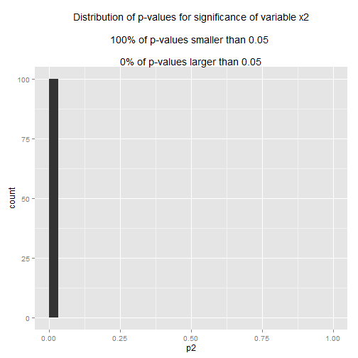

```r
ggplot(df, aes(x=p2)) + geom_histogram() + xlim(0,1) +
      ggtitle(paste0("Distribution of p-values for significance of variable x2\n\n",
                     round(100*mean(pvals[2,] < 0.05),1), "% of p-values smaller than 0.05 \n\n",
                     round(100*mean(pvals[2,] >= 0.05),1), "% of p-values larger than 0.05"))
```

The power of F test for main effects is equal 100%.

In this example it is not possible to find the power of F test for interactions because \( \mathrm{H_{alternative}} \) is not true (\( \mathrm{H_0} \) is that there are no interactions which is true).

### Create a scenario in which some interaction effects will be of the size 0.7. Use simulations to calculate the power of F test for main effects and power of test for interactions (since there are no main effects test for them should be on the level alpha).

```r
set.seed(77)

# only residuals
Y <- rnorm(N)

# adding interaction
Y[x1=="II" & x2=="B"] <- Y[x1=="II" & x2=="B"] + 0.9

myData2 <- data.frame(Y, x1, x2)
```

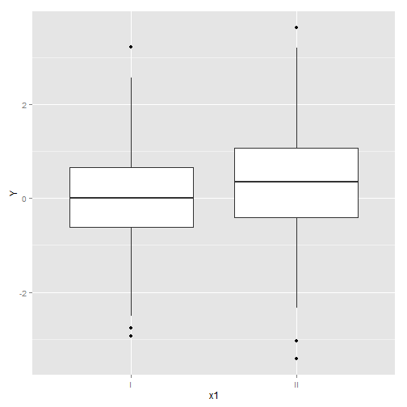

```r
library("ggplot2")
ggplot(myData2, aes(x=x1, y=Y)) + geom_boxplot()
```

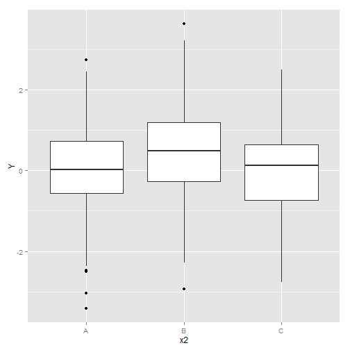

```r
ggplot(myData2, aes(x=x2, y=Y)) + geom_boxplot()
```

Boxplots do not show much diffrence in means between groups.

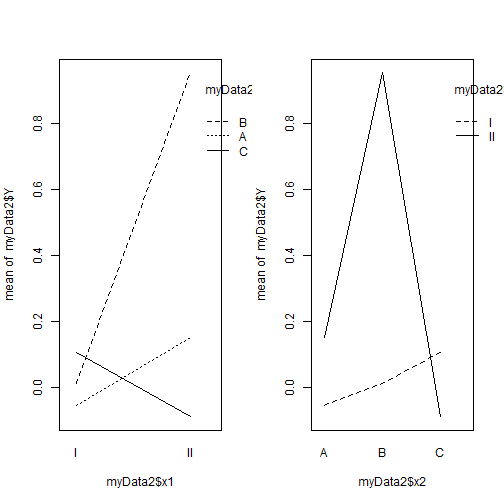

```r
par(mfrow=c(1,2))
interaction.plot(myData2$x1, myData2$x2, myData2$Y)
interaction.plot(myData2$x2, myData2$x1, myData2$Y)
```

Lines are not parallel, so there is clear evidence of interaction between x1 and x2.

```r
model1 <- lm(Y ~ x1 + x2, data = myData2)
summary(model1)
```

```
##
## Call:
## lm(formula = Y ~ x1 + x2, data = myData2)
##
## Residuals:
##     Min      1Q  Median      3Q     Max
## -3.6162 -0.6786 -0.0115  0.6809  2.9856
##
## Coefficients:
##             Estimate Std. Error t value Pr(>|t|)
## (Intercept) -0.11134    0.06701  -1.662   0.0969 .
## x1II         0.31801    0.06701   4.746 2.42e-06 ***
## x2B          0.43385    0.08207   5.286 1.57e-07 ***
## x2C         -0.03962    0.08207  -0.483   0.6294
## ---
## Signif. codes:  0 '***' 0.001 '**' 0.01 '*' 0.05 '.' 0.1 ' ' 1
##
## Residual standard error: 1.005 on 896 degrees of freedom
## Multiple R-squared:  0.06617,    Adjusted R-squared:  0.06305
## F-statistic: 21.16 on 3 and 896 DF,  p-value: 2.984e-13
```

We see that main effects are statistically significant when the model is not considering interactions.

```r
model2 <- lm(Y ~ x1 * x2, data = myData2)
summary(model2)
```

```
##
## Call:
## lm(formula = Y ~ x1 * x2, data = myData2)
##
## Residuals:
##     Min      1Q  Median      3Q     Max
## -3.5605 -0.6618 -0.0121  0.6415  3.2049
##
## Coefficients:
##             Estimate Std. Error t value Pr(>|t|)
## (Intercept) -0.05563    0.07986  -0.697   0.4863
## x1II         0.20657    0.11294   1.829   0.0677 .
## x2B          0.06559    0.11294   0.581   0.5615
## x2C          0.16148    0.11294   1.430   0.1531
## x1II:x2B     0.73652    0.15972   4.611 4.59e-06 ***
## x1II:x2C    -0.40221    0.15972  -2.518   0.0120 *
## ---
## Signif. codes:  0 '***' 0.001 '**' 0.01 '*' 0.05 '.' 0.1 ' ' 1
##
## Residual standard error: 0.9781 on 894 degrees of freedom
## Multiple R-squared:  0.1178, Adjusted R-squared:  0.1128
## F-statistic: 23.87 on 5 and 894 DF,  p-value: < 2.2e-16
```

But when we introduce the interactions, the main effects loose their significance. The interaction effect between groups II and B is of the size 0.7 (as the standard deviation equals 1 in our case).

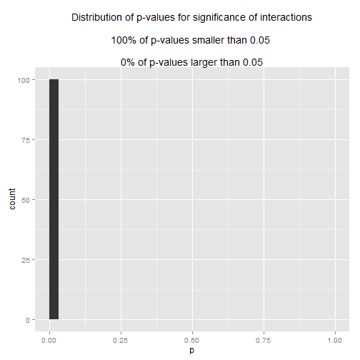

```r
set.seed(777)

M <- 100
pvals <- replicate(M, {

  Y <- rnorm(N)

  # adding interaction
  Y[x1=="II" & x2=="B"] <- Y[x1=="II" & x2=="B"] + 0.9

  myData2 <- data.frame(Y, x1=factor(x1), x2=factor(x2))

  summary(aov(Y~x1*x2, data=myData2))[[1]][3,5]
})

df <- data.frame(p=pvals)

ggplot(df, aes(x=p)) + geom_histogram() + xlim(0,1) +
      ggtitle(paste0("Distribution of p-values for significance of interactions\n\n",
                     round(100*mean(pvals < 0.05),1), "% of p-values smaller than 0.05 \n\n",
                     round(100*mean(pvals >= 0.05),1), "% of p-values larger than 0.05"))
```

The power of F test for interactions is equal 100%.

In this example it is not possible to find the power of F test for main effects because \( \mathrm{H_{alternative}} \) is not true.

### Create a scenario in which there are main effects and interaction effects of the size 0.7. Use simulations to calculate the power of F test for main effects and power of test for interactions.

```r
set.seed(77)

# only residuals
Y <- rnorm(N)

# differing means
Y[x1=="II"] <- Y[x1=="II"] + 0.5

Y[x2=="C"] <- Y[x2=="C"] + 0.7

# adding interactions
Y[x1=="II" & x2=="B"] <- Y[x1=="II" & x2=="B"] + 0.9

myData3 <- data.frame(Y, x1, x2)
```

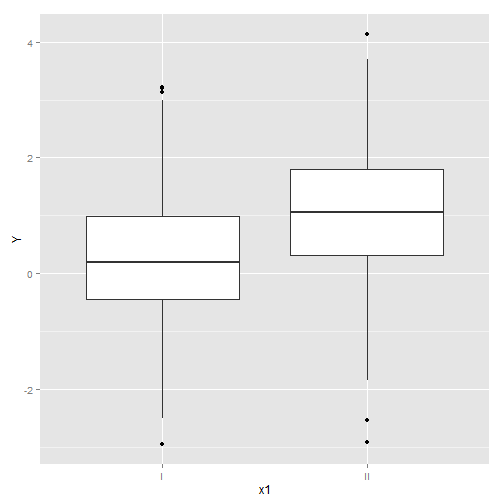

```r
library("ggplot2")
ggplot(myData3, aes(x=x1, y=Y)) + geom_boxplot()
```

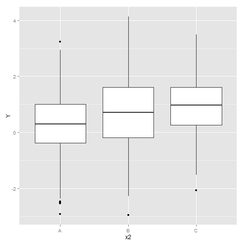

```r
ggplot(myData3, aes(x=x2, y=Y)) + geom_boxplot()
```

From the boxplots we see differences in means between groups.

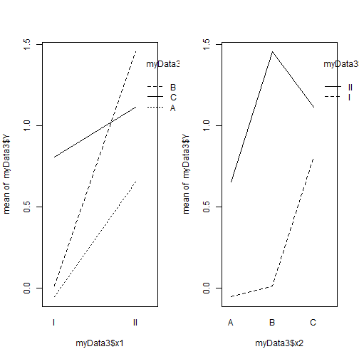

```r
par(mfrow=c(1,2))
interaction.plot(myData3$x1, myData3$x2, myData3$Y)
interaction.plot(myData3$x2, myData3$x1, myData3$Y)
```

Lines are not parallel, so there is evidence of interaction between x1 and x2.

```r
model1 <- lm(Y ~ x1 + x2, data = myData3)
summary(model1)
```

```
##
## Call:
## lm(formula = Y ~ x1 + x2, data = myData3)
##
## Residuals:
##     Min      1Q  Median      3Q     Max
## -3.6162 -0.6786 -0.0115  0.6809  2.9856
##
## Coefficients:
##             Estimate Std. Error t value Pr(>|t|)
## (Intercept) -0.11134    0.06701  -1.662   0.0969 .
## x1II         0.81801    0.06701  12.207  < 2e-16 ***
## x2B          0.43385    0.08207   5.286 1.57e-07 ***
## x2C          0.66038    0.08207   8.046 2.70e-15 ***
## ---
## Signif. codes:  0 '***' 0.001 '**' 0.01 '*' 0.05 '.' 0.1 ' ' 1
##
## Residual standard error: 1.005 on 896 degrees of freedom
## Multiple R-squared:  0.1942, Adjusted R-squared:  0.1915
## F-statistic: 71.96 on 3 and 896 DF,  p-value: < 2.2e-16
```

We see that main effects are statistically significant.

```r
model2 <- lm(Y ~ x1 * x2, data = myData3)
summary(model2)
```

```
##
## Call:
## lm(formula = Y ~ x1 * x2, data = myData3)
##
## Residuals:
##     Min      1Q  Median      3Q     Max
## -3.5605 -0.6618 -0.0121  0.6415  3.2049
##
## Coefficients:
##             Estimate Std. Error t value Pr(>|t|)
## (Intercept) -0.05563    0.07986  -0.697    0.486
## x1II         0.70657    0.11294   6.256 6.11e-10 ***
## x2B          0.06559    0.11294   0.581    0.562
## x2C          0.86148    0.11294   7.628 6.11e-14 ***
## x1II:x2B     0.73652    0.15972   4.611 4.59e-06 ***
## x1II:x2C    -0.40221    0.15972  -2.518    0.012 *
## ---
## Signif. codes:  0 '***' 0.001 '**' 0.01 '*' 0.05 '.' 0.1 ' ' 1
##
## Residual standard error: 0.9781 on 894 degrees of freedom
## Multiple R-squared:  0.2387, Adjusted R-squared:  0.2344
## F-statistic: 56.06 on 5 and 894 DF,  p-value: < 2.2e-16
```

Also interactions are significant.

The main effect for group II is of the size 0.7, as well as the interaction effect between groups II and B.

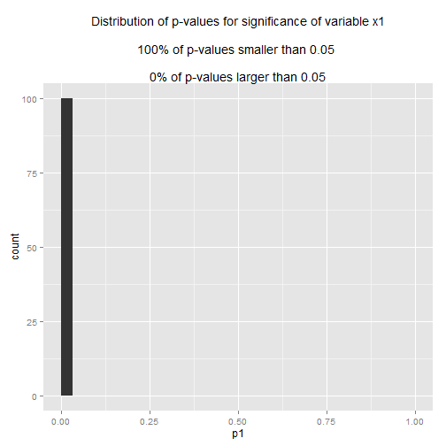

```r
set.seed(777)

M <- 100
pvals <- replicate(M, {

  Y <- rnorm(N)

  # differing means
  Y[x1=="II"] <- Y[x1=="II"] + 0.5

  Y[x2=="C"] <- Y[x2=="C"] + 0.7

  # adding interactions
  Y[x1=="II" & x2=="B"] <- Y[x1=="II" & x2=="B"] + 0.9

  myData3 <- data.frame(Y, x1=factor(x1), x2=factor(x2))

  tmp <- summary(aov(Y~x1*x2, data=myData3))
  c(tmp[[1]][1,5], tmp[[1]][2,5], tmp[[1]][3,5])
})

df <- data.frame(p1=pvals[1,], p2=pvals[2,], p3=pvals[3,])

ggplot(df, aes(x=p1)) + geom_histogram() + xlim(0,1) +
      ggtitle(paste0("Distribution of p-values for significance of variable x1\n\n",
                     round(100*mean(pvals[1,] < 0.05),1), "% of p-values smaller than 0.05 \n\n",
                     round(100*mean(pvals[1,] >= 0.05),1), "% of p-values larger than 0.05"))
```

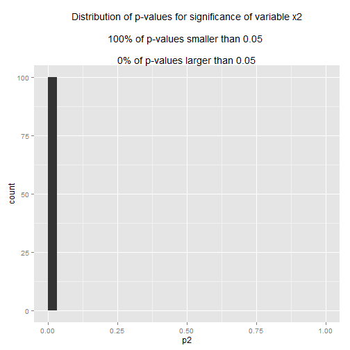

```r
ggplot(df, aes(x=p2)) + geom_histogram() + xlim(0,1) +
      ggtitle(paste0("Distribution of p-values for significance of variable x2\n\n",
                     round(100*mean(pvals[2,] < 0.05),1), "% of p-values smaller than 0.05 \n\n",
                     round(100*mean(pvals[2,] >= 0.05),1), "% of p-values larger than 0.05"))
```

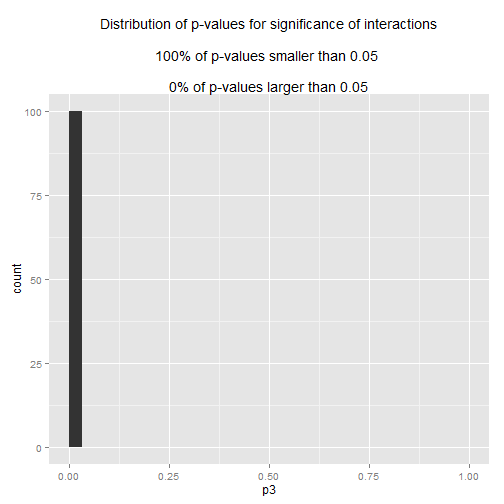

```r
ggplot(df, aes(x=p3)) + geom_histogram() + xlim(0,1) +
      ggtitle(paste0("Distribution of p-values for significance of interactions\n\n",
                     round(100*mean(pvals < 0.05),1), "% of p-values smaller than 0.05 \n\n",
                     round(100*mean(pvals >= 0.05),1), "% of p-values larger than 0.05"))
```

The power of F test for main effects as well as for interactions is equal 100%.